# Презентация по лабораторной работе №2.

Дисциплина: Операционные системы.

Лобанова П. И.

Российский университет дружбы народов, Москва, Россия

Факультет физико-математических и естественных наук

17.02.2023

# Информация

## Докладчик

- Лобанова Полина Иннокентьевна
- Студентка факультета физико-математических и естественных наук
- Учащаяся направления “Математика и механика”
- Российский университет дружбы народов
- polla-2004@mail.ru

# Цель работы

Изучить идеологию и применение средств контроля версий. Освоить умения по работе с git.

# Ход работы

## Установка git и gh

На первом этапе необходимо установить и настроить git, а также установить gh.

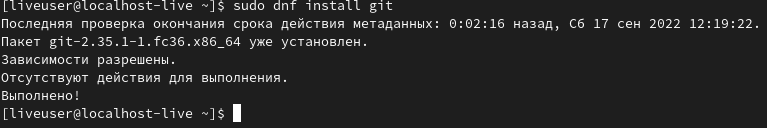

*Установка git.*

## Создание ssh, pgp ключей

Далее я создала ssh, pgp ключи и добавила их на github.

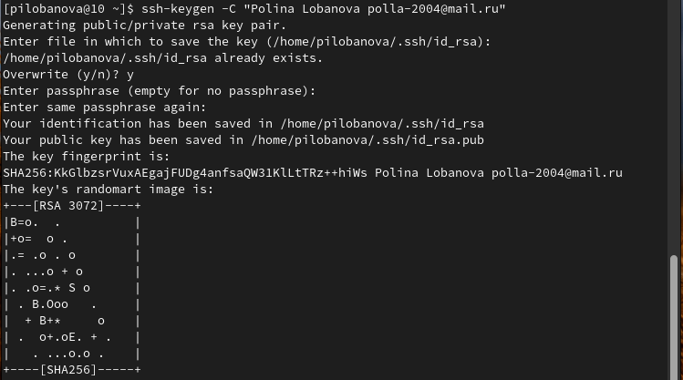

*Создание ssh ключа.*

## Настройка автоматических подписей коммитов git

Следующим этапом была настройка автоматических подписей коммитов git и настройка gh.

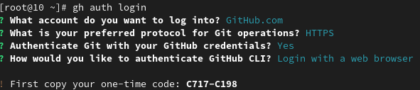

*Авторизация gh.*

## Создание репозитория курса

Далее мне было необходимо создать репозиторий курса в соответствии с шаблоном.

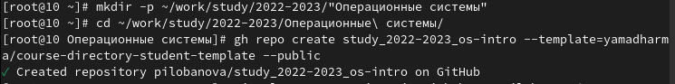

*Создание репозитория.*

## Создание каталога курса

После того, как я создала репозиторий, мне нужно было создать каталог курса.

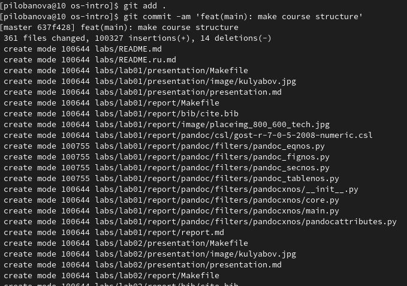

*Создание каталога курса.*

## Контрольные вопросы

Что такое системы контроля версий (VCS) и для решения каких задач они предназначаются? Объясните следующие понятия VCS и их отношения: хранилище, commit, история, рабочая копия. Что представляют собой и чем отличаются централизованные и децентрализованные VCS? Приведите примеры VCS каждого вида. Опишите действия с VCS при единоличной работе с хранилищем. Опишите порядок работы с общим хранилищем VCS. Каковы основные задачи, решаемые инструментальным средством git? Назовите и дайте краткую характеристику командам git. Приведите примеры использования при работе с локальным и удалённым репозиториями. Что такое и зачем могут быть нужны ветви (branches)? Как и зачем можно игнорировать некоторые файлы при commit?

# Вывод

Я изучила идеологию и применение средств контроля версий и научилась работать с git.